# credit_data_analysis_notebook

## Исследование данных для системы финансового скоринга

Цель исследования – оценить влияние различных факторов на способность клиентов погасить кредит вовремя.

Описание данных:

```
• children — количество детей в семье

• days_employed — общий трудовой стаж в днях

• dob_years — возраст клиента в годах

• education — уровень образования клиента

• education_id — идентификатор уровня образования

• family_status — семейное положение

• family_status_id — идентификатор семейного положения

• gender — пол клиента

• income_type — тип занятости

• debt — имел ли задолженность по возврату кредитов

• total_income — ежемесячный доход

• purpose — цель получения кредита
```

# Импорт модулей

```python
import os
import pandas as pd
import matplotlib.pyplot as plt
import plotly.express as px
from plotly.subplots import make_subplots
```

# Константы

```python
DATA_PATH = "data"
DATASET_PATH = os.path.join(DATA_PATH, "credit_data.csv")
```

# Загрузка данных

```python
clients_df = pd.read_csv(DATASET_PATH)
```

```python
clients_df.head(10)
```

|  | children | days_employed | dob_years | education | education_id | family_status | family_status_id | gender | income_type | debt | total_income | purpose |
| --- | --- | --- | --- | --- | --- | --- | --- | --- | --- | --- | --- | --- |
| 0 | 1 | -8437.673028 | 42 | высшее | 0 | женат / замужем | 0 | F | сотрудник | 0 | 253875.639453 | покупка жилья |
| 1 | 1 | -4024.803754 | 36 | среднее | 1 | женат / замужем | 0 | F | сотрудник | 0 | 112080.014102 | приобретение автомобиля |
| 2 | 0 | -5623.422610 | 33 | Среднее | 1 | женат / замужем | 0 | M | сотрудник | 0 | 145885.952297 | покупка жилья |
| 3 | 3 | -4124.747207 | 32 | среднее | 1 | женат / замужем | 0 | M | сотрудник | 0 | 267628.550329 | дополнительное образование |
| 4 | 0 | 340266.072047 | 53 | среднее | 1 | гражданский брак | 1 | F | пенсионер | 0 | 158616.077870 | сыграть свадьбу |
| 5 | 0 | -926.185831 | 27 | высшее | 0 | гражданский брак | 1 | M | компаньон | 0 | 255763.565419 | покупка жилья |
| 6 | 0 | -2879.202052 | 43 | высшее | 0 | женат / замужем | 0 | F | компаньон | 0 | 240525.971920 | операции с жильем |
| 7 | 0 | -152.779569 | 50 | СРЕДНЕЕ | 1 | женат / замужем | 0 | M | сотрудник | 0 | 135823.934197 | образование |
| 8 | 2 | -6929.865299 | 35 | ВЫСШЕЕ | 0 | гражданский брак | 1 | F | сотрудник | 0 | 95856.832424 | на проведение свадьбы |
| 9 | 0 | -2188.756445 | 41 | среднее | 1 | женат / замужем | 0 | M | сотрудник | 0 | 144425.938277 | покупка жилья для семьи |

```python
clients_df.info()
```

```
<class 'pandas.core.frame.DataFrame'>
RangeIndex: 21525 entries, 0 to 21524
Data columns (total 12 columns):
 #   Column            Non-Null Count  Dtype
---  ------            --------------  -----
 0   children          21525 non-null  int64
 1   days_employed     19351 non-null  float64
 2   dob_years         21525 non-null  int64
 3   education         21525 non-null  object
 4   education_id      21525 non-null  int64
 5   family_status     21525 non-null  object
 6   family_status_id  21525 non-null  int64
 7   gender            21525 non-null  object
 8   income_type       21525 non-null  object
 9   debt              21525 non-null  int64
 10  total_income      19351 non-null  float64
 11  purpose           21525 non-null  object
dtypes: float64(2), int64(5), object(5)
memory usage: 2.0+ MB
```

# Предобработка данных

Выведите количество пропущенных значений для каждого столбца.

```python
clients_df.isna().sum()
```

```
children               0
days_employed       2174
dob_years              0
education              0
education_id           0
family_status          0
family_status_id       0
gender                 0
income_type            0
debt                   0
total_income        2174
purpose                0
dtype: int64
```

Заполните столбец с пропущенными значениями — total_income — хранит данные о доходах. На сумму дохода сильнее всего влияет тип занятости, поэтому заполнить пропуски в этом столбце нужно медианным значением по каждому типу из столбца income_type. Например, у человека с типом занятости сотрудник пропуск в столбце total_income должен быть заполнен медианным доходом среди всех записей с тем же типом.

```python
income_type_dict = dict.fromkeys(set(clients_df["income_type"]), None)
```

```python
for income_type in income_type_dict.keys():
    income_type_dict[income_type] = clients_df[clients_df["income_type"] == income_type]["total_income"].median(skipna=True)
```

```python
i = 0
total_income_na_indexes_values = {}
total_income_na = clients_df["total_income"].isna()
for total_income_value in total_income_na:
    if total_income_value:
        total_income_na_indexes_values[i] = income_type_dict[clients_df["income_type"].iloc[i]]
    i += 1
```

```python
for index in total_income_na_indexes_values.keys():
    clients_df.at[index, "total_income"] = total_income_na_indexes_values[index]
```

Просмотрите столбцы на предмет аномальных значений и выбросов. Выяснить, в каких столбцах они есть, исправить.

Ищем аномалии в числовых столбцах

```python
def prepare_figure(dataframe, primary_data_columns_names, secondary_data_columns_names=None, height=600, width=1200, x_axis_column=None, title_text=None):
    dataframe = dataframe.copy()
    if x_axis_column is not None:
        dataframe = dataframe.set_index(x_axis_column)
    if secondary_data_columns_names is not None:
        assert set(primary_data_columns_names + secondary_data_columns_names).issubset(
            dataframe.columns), f"not existing data column. can plot any of {list(dataframe.columns)}"
    figure = make_subplots(specs=[[{"secondary_y": True}]])
    fig_y1 = px.line(dataframe[primary_data_columns_names])["data"]
    for trace in range(len(fig_y1)):
        figure.add_trace(fig_y1[trace], secondary_y=False)
    if secondary_data_columns_names is not None:
        fig_y2 = px.line(dataframe[secondary_data_columns_names])["data"]
        for trace in range(len(fig_y2)):
            figure.add_trace(fig_y2[trace], secondary_y=True)
    figure.update_xaxes()
    figure.update_yaxes(secondary_y=False)
    figure.update_yaxes(secondary_y=True)
    figure.update_layout(showlegend=True, height=height, width=width, title_text=title_text)
    return figure
```

```python
figure = prepare_figure(clients_df, ["days_employed",
                                     "days_employed_changed",
                                     "dob_years",
                                     "total_income"],
                        ["children",
                         "education_id",
                         "family_status_id",
                         "debt"])
```

```python
figure.show()
```

[interactive chart not shown]

```
array([[<Axes: title={'center': 'children'}>,
        <Axes: title={'center': 'days_employed'}>,
        <Axes: title={'center': 'dob_years'}>],
       [<Axes: title={'center': 'education_id'}>,
        <Axes: title={'center': 'family_status_id'}>,
        <Axes: title={'center': 'debt'}>],
       [<Axes: title={'center': 'total_income'}>,
        <Axes: title={'center': 'days_employed_changed'}>, <Axes: >]],
      dtype=object)
```

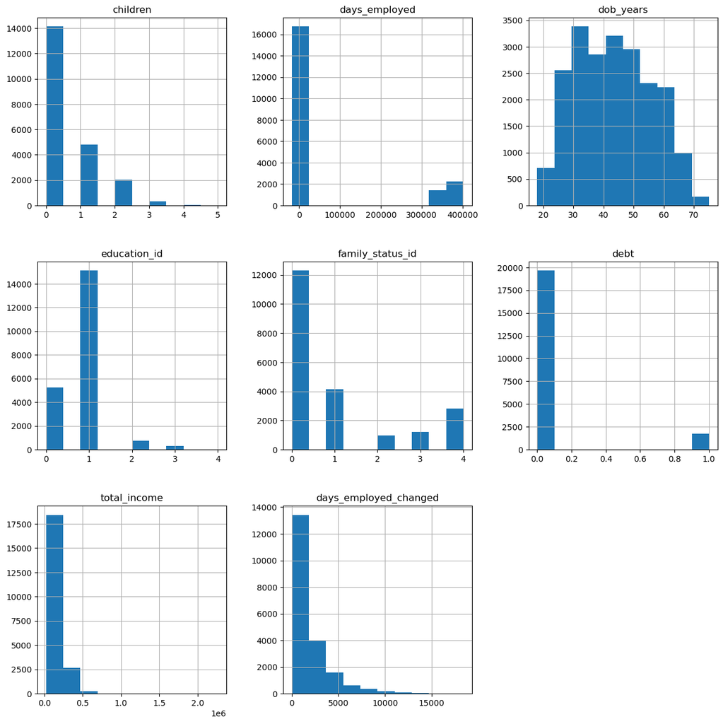

```python
clients_df.hist(figsize=(15, 15))
```

```python
(clients_df["days_employed"].min(), clients_df["days_employed"].max())
```

```
(-18388.949900568383, 401755.40047533)
```

```python
(clients_df["dob_years"].min(), clients_df["dob_years"].max())
```

```
(0, 75)
```

```python
(clients_df["children"].min(), clients_df["children"].max())
```

```
(-1, 20)
```

"days_employed": трудовой стаж не может измеряться в сотнях тысяч дней или быть отрицательным

"dob_years": возраст клиента не может быть меньше 18, но в столбце есть нулевые значения

"children": не божет быть детей 20 или -1

```python
clients_df["dob_years"] = clients_df["dob_years"].clip(lower=18)
```

Ищем аномалии в категориальных столбцах

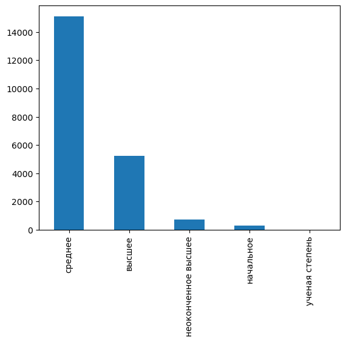

```python
clients_df['education'].value_counts().plot(kind='bar')
```

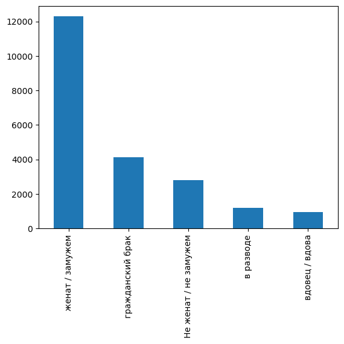

```python
clients_df['family_status'].value_counts().plot(kind='bar')
```

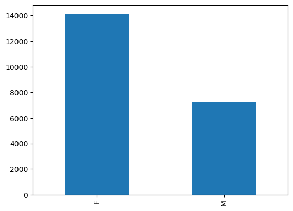

```python
clients_df['gender'].value_counts().plot(kind='bar')
```

```python
clients_df[clients_df['gender'] == 'XNA']
```

|  | children | days_employed | dob_years | education | education_id | family_status | family_status_id | gender | income_type | debt | total_income | purpose |
| --- | --- | --- | --- | --- | --- | --- | --- | --- | --- | --- | --- | --- |
| 10701 | 0 | -2358.600502 | 24 | неоконченное высшее | 2 | гражданский брак | 1 | XNA | компаньон | 0 | 203905.157261 | покупка недвижимости |

```python
clients_df = clients_df[clients_df['gender'] != 'XNA']
```

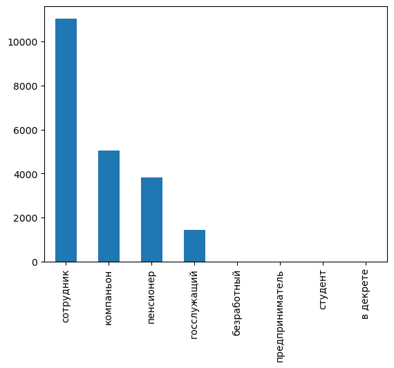

```python
clients_df['income_type'].value_counts().plot(kind='bar')
```

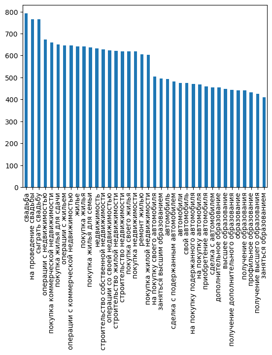

```python
clients_df['purpose'].value_counts().plot(kind='bar')
```

Для каждого типа занятости выведите медианное значение трудового стажа в днях из столбца days_employed. Посмотрите, все ли в порядке. Напишите вывод.

```python
income_type_days_employed_dict = {}
for income_type in income_type_dict.keys():
    income_type_days_employed_dict[income_type] = clients_df[clients_df["income_type"] == income_type]["days_employed"].median(skipna=True)
income_type_days_employed_dict
```

```
{'в декрете': -3296.7599620220594,
 'предприниматель': -520.8480834953765,
 'пенсионер': 365213.3062657312,
 'сотрудник': -1574.2028211070854,
 'госслужащий': -2689.3683533043886,
 'компаньон': -1546.3332141566746,
 'безработный': 366413.65274420456,
 'студент': -578.7515535382181}
```

в столбце "days_employed" всё не нормально. попробую обратить его и удалить отрицательные значения

```python
clients_df["days_employed_changed"] = (clients_df["days_employed"] * -1).clip(lower=0)
```

```python
income_type_days_employed_changed_dict = {}
for income_type in income_type_dict.keys():
    income_type_days_employed_changed_dict[income_type] = clients_df[clients_df["income_type"] == income_type]["days_employed_changed"].median(skipna=True)
income_type_days_employed_changed_dict
```

```
{'в декрете': 3296.7599620220594,
 'предприниматель': 520.8480834953765,
 'пенсионер': 0.0,
 'сотрудник': 1574.2028211070854,
 'госслужащий': 2689.3683533043886,
 'компаньон': 1546.3332141566746,
 'безработный': 0.0,
 'студент': 578.7515535382181}
```

в измененном столбце странно что для пенсионеров медианный трудовой стаж - 0 дней

Заполните пропуски в столбце days_employed медианными значениями по каждому типу занятости income_type.

```python
i = 0
days_employed_na_indexes_values = {}
days_employed_na = clients_df["days_employed"].isna()
for days_employed_value in days_employed_na:
    if days_employed_value:
        days_employed_na_indexes_values[i] = income_type_days_employed_dict[clients_df["income_type"].iloc[i]]
    i += 1
for index in days_employed_na_indexes_values.keys():
    clients_df.at[index, "days_employed"] = days_employed_na_indexes_values[index]
```

```python
i = 0
days_employed_changed_na_indexes_values = {}
days_employed_changed_na = clients_df["days_employed_changed"].isna()
for days_employed_changed_value in days_employed_changed_na:
    if days_employed_changed_value:
        days_employed_changed_na_indexes_values[i] = income_type_days_employed_changed_dict[clients_df["income_type"].iloc[i]]
    i += 1
for index in days_employed_changed_na_indexes_values.keys():
    clients_df.at[index, "days_employed_changed"] = days_employed_changed_na_indexes_values[index]
```

```python
(clients_df["days_employed_changed"].min(), clients_df["days_employed_changed"].max())
```

```
(0.0, 18388.949900568383)
```

Выведите перечень уникальных значений столбца children. Удалите строки с аномальными значениями.

```python
set(clients_df["children"])
```

```
{-1, 0, 1, 2, 3, 4, 5, 20}
```

```python
clients_df = clients_df[clients_df["children"] != -1][clients_df["children"] != 20]
```

Обработайте неявные дубликаты в столбце education. В этом столбце есть одни и те же значения, но записанные по-разному: с использованием заглавных и строчных букв. Приведите их к нижнему регистру.

```python
clients_df["education"] = clients_df["education"].str.lower()
```

Выведите на экран количество строк-дубликатов в данных. Если такие строки присутствуют, удалите их.

```python
len(clients_df) - len(clients_df.drop_duplicates())
```

```
34
```

```python
clients_df = clients_df.drop_duplicates()
```

На основании диапазонов, указанных ниже, создайте в датафрейме data столбец total_income_category с категориями:

```
• 0–30000 — 'E';

• 30001–50000 — 'D';

• 50001–200000 — 'C'

• 200001–1000000 — 'B';

• 1000001 и выше — 'A'.
```

```python
def total_income_category(value):
    if value <= 30_000:
        return "E"
    if 30_000 < value <= 50_000:
        return "D"
    elif 50_000 < value <= 200_000:
        return "C"
    elif 200_000 < value <= 1_000_000:
        return "B"
    elif value > 1_000_000:
        return "A"
```

```python
clients_df["total_income_category"] = clients_df["total_income"].map(total_income_category)
```

```python
display(clients_df.head())
```

|  | children | days_employed | dob_years | education | education_id | family_status | family_status_id | gender | income_type | debt | total_income | purpose | days_employed_changed | total_income_category |
| --- | --- | --- | --- | --- | --- | --- | --- | --- | --- | --- | --- | --- | --- | --- |
| 0 | 1 | -8437.673028 | 42 | высшее | 0 | женат / замужем | 0 | F | сотрудник | 0 | 253875.639453 | покупка жилья | 8437.673028 | B |
| 1 | 1 | -4024.803754 | 36 | среднее | 1 | женат / замужем | 0 | F | сотрудник | 0 | 112080.014102 | приобретение автомобиля | 4024.803754 | C |
| 2 | 0 | -5623.422610 | 33 | среднее | 1 | женат / замужем | 0 | M | сотрудник | 0 | 145885.952297 | покупка жилья | 5623.422610 | C |
| 3 | 3 | -4124.747207 | 32 | среднее | 1 | женат / замужем | 0 | M | сотрудник | 0 | 267628.550329 | дополнительное образование | 4124.747207 | B |
| 4 | 0 | 340266.072047 | 53 | среднее | 1 | гражданский брак | 1 | F | пенсионер | 0 | 158616.077870 | сыграть свадьбу | 0.000000 | C |

Рассмотрите перечень уникальных целей взятия кредита из столбца purpose. Присвойте каждой строке категорию по содержанию текста в столбце (ориентируйтесь на ключевые слова).

```
• 'операции с автомобилем',

• 'операции с недвижимостью',

• 'проведение свадьбы',

• 'получение образования'.
```

```python
purposes = list(set(clients_df['purpose']))
```

```python
def purpose_category(value: str) -> str:
    if "авто" in value:
        return 'операции с автомобилем'
    elif "жил" in value or "недвиж" in value:
        return 'операции с недвижимостью'
    elif "свад" in value:
        return 'проведение свадьбы'
    elif "образов" in value:
        return 'получение образования'
    else:
        return "OTHER"
```

```python
purpose_categories = {purpose: purpose_category(purpose) for purpose in purposes}
```

```python
clients_df["purpose_category"] = clients_df["purpose"].map(purpose_category)
```

```python
clients_df.head(10)
```

|  | children | days_employed | dob_years | education | education_id | family_status | family_status_id | gender | income_type | debt | total_income | purpose | days_employed_changed | total_income_category | purpose_category |
| --- | --- | --- | --- | --- | --- | --- | --- | --- | --- | --- | --- | --- | --- | --- | --- |
| 0 | 1 | -8437.673028 | 42 | высшее | 0 | женат / замужем | 0 | F | сотрудник | 0 | 253875.639453 | покупка жилья | 8437.673028 | B | операции с недвижимостью |
| 1 | 1 | -4024.803754 | 36 | среднее | 1 | женат / замужем | 0 | F | сотрудник | 0 | 112080.014102 | приобретение автомобиля | 4024.803754 | C | операции с автомобилем |
| 2 | 0 | -5623.422610 | 33 | среднее | 1 | женат / замужем | 0 | M | сотрудник | 0 | 145885.952297 | покупка жилья | 5623.422610 | C | операции с недвижимостью |
| 3 | 3 | -4124.747207 | 32 | среднее | 1 | женат / замужем | 0 | M | сотрудник | 0 | 267628.550329 | дополнительное образование | 4124.747207 | B | получение образования |
| 4 | 0 | 340266.072047 | 53 | среднее | 1 | гражданский брак | 1 | F | пенсионер | 0 | 158616.077870 | сыграть свадьбу | 0.000000 | C | проведение свадьбы |
| 5 | 0 | -926.185831 | 27 | высшее | 0 | гражданский брак | 1 | M | компаньон | 0 | 255763.565419 | покупка жилья | 926.185831 | B | операции с недвижимостью |
| 6 | 0 | -2879.202052 | 43 | высшее | 0 | женат / замужем | 0 | F | компаньон | 0 | 240525.971920 | операции с жильем | 2879.202052 | B | операции с недвижимостью |
| 7 | 0 | -152.779569 | 50 | среднее | 1 | женат / замужем | 0 | M | сотрудник | 0 | 135823.934197 | образование | 152.779569 | C | получение образования |
| 8 | 2 | -6929.865299 | 35 | высшее | 0 | гражданский брак | 1 | F | сотрудник | 0 | 95856.832424 | на проведение свадьбы | 6929.865299 | C | проведение свадьбы |
| 9 | 0 | -2188.756445 | 41 | среднее | 1 | женат / замужем | 0 | M | сотрудник | 0 | 144425.938277 | покупка жилья для семьи | 2188.756445 | C | операции с недвижимостью |